# FigureYa316RF_XGBoost_Boruta

**Author(s)**: Guoqi Li; Yasi Zhang  
**Reviewer(s)**: Ying Ge  
**Date**: 2025-05-20

# 需求描述

# Demand description

想众筹这篇文章的Figure S2；就是用4种机器学习来筛选生物标志物。

We want to crowdfund Figure S2 from this paper; which uses 4 machine learning methods to screen biomarkers.

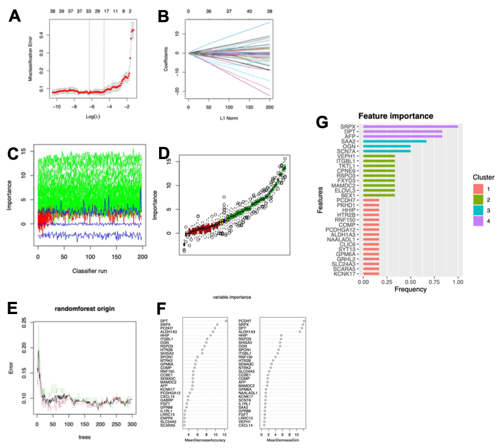

出自：https://www.ijbs.com/v18p0360

通过LASSO、SVM-RFE、随机森林(RF)和XGBoost算法，分别筛选出36、15、35和31个基于mRNAsi表型的差异表达基因(DEGs)，各算法的具体结果如图S2所示。

Source: https://www.ijbs.com/v18p0360

A total of 36, 15, 35 and 31 mRNAsi phenotype-based DEGs were selected by LASSO, SVM-RFE, RF and XGBoost, separately; results of each algorithm were shown in Figure S2.

# 应用场景

# Application scenarios

文章补充图2中展示的图形为4种算法的结果（LASSO，XGBoost，RF，Boruta），但方法学描述的确是5种（LASSO，SVM-REF，XGBoost，RF，Boruta）。

其中XGBoost是我们第一次众筹。FigureYa65SVM已经实现了前两种（LASSO，SVM-REF），本文档实现3种算法（XGBoost，RF，Boruta）。

我们众筹过的LASSO、SVM-REF、RF和Boruta如下。作者不同，可对比学习。

LASSO

- FigureYa31lasso https://k.youshop10.com/BflugKvZ
- FigureYa65SVM https://k.youshop10.com/5RZm-I9h
- FigureYa128Prognostic https://k.youshop10.com/5be2BiFs
- FigureYa220repeatedLasso https://k.youshop10.com/4TzImkC6
- FigureYa238corRiskMut https://k.youshop10.com/nUP=aC-n
- FigureYa293machineLearning https://k.youshop10.com/vkyERKZ7
- FigureYa45iCluster https://k.youshop10.com/puSQ=xuo

SVM-REF

- FigureYa65SVM https://k.youshop10.com/5RZm-I9h
- FigureYa130coxSVM https://k.youshop10.com/eUd6aHnK
- FigureYa217RMR https://k.youshop10.com/S6owwKd8
- FigureYa293machineLearning https://k.youshop10.com/vkyERKZ7

RF

- FigureYa159LR_RF https://k.youshop10.com/YgeCQyJm
- FigureYa184ranger https://k.youshop10.com/ZvyyYkr9
- FigureYa221tenFoldRF https://k.youshop10.com/3mnuaz7y

Boruta

- FigureYa204PCAscore https://k.youshop10.com/=bRTDwW7，不同于常规的lasso, cox回归系数与基因表达量的乘积，这篇文章采用Boruta降维，联合主成分分析第一主成分构建 signature score，特别适合做分子分型分析。

另外，我们众筹过的FigureYa可以实现文中的几个图：

- Figure 1A，可以用FigureYa161stemness来计算mRNAsi并画图。
- Figure 2A，可参考FigureYa71ssGSEAhttps://k.youshop10.com/hhH631te。
- Figure 2B，ESTIMATE可参考FigureYa211multiCohortImmSubtypehttps://k.youshop10.com/VwpAWxx0或FigureYa230immunelandscapehttps://k.youshop10.com/wQSoNWJ0，相关性展示可参考https://k.youshop10.com/Eig1YOB4。
- Figure 2D，CIBERSORT可参考FigureYa211multiCohortImmSubtypehttps://k.youshop10.com/VwpAWxx0，画图可参考FigureYa12boxhttps://k.youshop10.com/GyC0Qm3g
- Figure 3C，ClusterProfiler衔接GOplot可参考FigureYa52GOplothttps://k.youshop10.com/DmEbg3iO
- Figure 3E，可参考FigureYa69cancerSubtypeshttps://k.youshop10.com/kdKt1Kit
- Figure 5K，可参考FigureYa131CMaphttps://k.youshop10.com/7kOjUwPe
- Figure 6D，可参考FigureYa102multipanelROChttps://k.youshop10.com/7bYkTnXu

Figure S2 displays the results of four algorithms (LASSO, XGBoost, Random Forest [RF], and Boruta), while the Methods section describes five algorithms (LASSO, SVM-RFE, XGBoost, RF, and Boruta).

This represents our first crowdfunding initiative for XGBoost implementation. FigureYa65SVM has already covered the first two algorithms (LASSO and SVM-RFE), while this document implements the remaining three (XGBoost, RF, and Boruta).

For reference, our previous crowdfunded implementations of LASSO, SVM-RFE, RF, and Boruta (from different authors) are listed below for comparative study.

LASSO

- FigureYa31lasso https://k.youshop10.com/BflugKvZ
- FigureYa65SVM https://k.youshop10.com/5RZm-I9h
- FigureYa128Prognostic https://k.youshop10.com/5be2BiFs
- FigureYa220repeatedLasso https://k.youshop10.com/4TzImkC6
- FigureYa238corRiskMut https://k.youshop10.com/nUP=aC-n
- FigureYa293machineLearning https://k.youshop10.com/vkyERKZ7
- FigureYa45iCluster https://k.youshop10.com/puSQ=xuo

SVM-REF

- FigureYa65SVM https://k.youshop10.com/5RZm-I9h
- FigureYa130coxSVM https://k.youshop10.com/eUd6aHnK
- FigureYa217RMR https://k.youshop10.com/S6owwKd8
- FigureYa293machineLearning https://k.youshop10.com/vkyERKZ7

RF

- FigureYa159LR_RF https://k.youshop10.com/YgeCQyJm
- FigureYa184ranger https://k.youshop10.com/ZvyyYkr9
- FigureYa221tenFoldRF https://k.youshop10.com/3mnuaz7y

Boruta

- FigureYa204PCAscore https://k.youshop10.com/=bRTDwW7，Unlike conventional methods that multiply LASSO/Cox regression coefficients with gene expression values, this study employs Boruta for feature selection combined with the first principal component from PCA to construct signature scores - an approach particularly well-suited for molecular subtyping analysis.

In addition, the FigureYa we have crowdfunded can realize several of the images mentioned in the figure:

- Figure 1A, Use FigureYa161stemness to calculate mRNAsi and generate plots.
- Figure 2A, Refer to FigureYa71ssGSEA https://k.youshop10.com/hhH631te.
- Figure 2B, For ESTIMATE analysis, see FigureYa211multiCohortImmSubtype https://k.youshop10.com/VwpAWxx0 or FigureYa230immunelandscape https://k.youshop10.com/wQSoNWJ0; for correlation visualization, usehttps://k.youshop10.com/Eig1YOB4
- Figure 2D, CIBERSORT implementation via FigureYa211multiCohortImmSubtype https://k.youshop10.com/VwpAWxx0, with plotting templates from FigureYa12box https://k.youshop10.com/GyC0Qm3g.
- Figure 3C, Integrate ClusterProfiler with GOplot using FigureYa52GOplot https://k.youshop10.com/DmEbg3iO.
- Figure 3E, Adapt FigureYa69cancerSubtypes https://k.youshop10.com/kdKt1Kit.
- Figure 5K, Leverage FigureYa131CMaphttps://k.youshop10.com/7kOjUwPe.
- Figure 6D, Reproduce using FigureYa102multipanelROC https://k.youshop10.com/7bYkTnXu.

# 环境设置

# Requirements Description

使用国内镜像安装包。

Using domestic mirrors for package installation.

```r
options("repos"= c(CRAN="https://mirrors.tuna.tsinghua.edu.cn/CRAN/"))
options(BioC_mirror="http://mirrors.tuna.tsinghua.edu.cn/bioconductor/")
BiocManager::install("randomForest")
```

```r
# 显示英文报错信息
# Show English error messages
Sys.setenv(LANGUAGE = "en")

# 禁止chr转成factor
# Prevent character-to-factor conversion
options(stringsAsFactors = FALSE)
```

# 输入文件

# Input Files

easy_input.csv，带有分组信息的矩阵。来自FigureYa65 https://k.youshop10.com/5RZm-I9h。

可自行准备，至少包含以下信息：

- 第一列：sample ID
- 第二列：样本分组信息，最好为二分类变量
- 第三列之后：表达矩阵

easy_input.csv, matrix with grouping information. From FigureYa65 https://k.youshop10.com/5RZm-I9h.

Can be prepared by yourself, must contain at least:

- First column: sample ID
- Second column: sample grouping info, preferably binary
- Third column onwards: expression matrix

```r
# 读取数据
# Read data
data <- read.csv("easy_input.csv", row.names = 1, as.is = F)
set.seed(100)
```